# OSTA5003 Project Final Report

Authors

Yawei XI (550827289)

Yifeng LIN (560316872)

## Problem Statement

In the contemporary digital music landscape, streaming platforms leverage sophisticated algorithms to optimize content discovery and organization. A critical component of this infrastructure is automated genre classification, a non-trivial task complicated by the inherent high-cardinality of musical labels and the significant semantic overlap between acoustic feature distributions. This project leverages the Spotify Tracks dataset[^1], comprising 114,000 observations across 114 distinct genres, to address the challenge of high-dimensional genre classification. The objective is to design and validate a robust predictive framework that synthesizes continuous acoustic features—such as danceability, energy, and tempo—with textual metadata, ultimately pushing the boundaries of classification accuracy in high-cardinality multi-class environments.

## Dataset Description

The Spotify Tracks dataset contains 114,000 audio tracks classified into 114 unique genres. It integrates textual metadata, binary status flags, and continuous acoustic descriptors derived from Spotify’s internal audio analysis algorithms. This dataset is designed for multi-class genre classification and analysis of musical characteristics.

Column Descriptions

- `track_id`: Unique track identifier.
- `artists`: Semicolon-separated names of performing artists.
- `album_name`: Name of the album containing the track.
- `track_name`: Title of the track.
- `popularity`: Popularity score (0–100) based on play count and recency.
- `duration_ms`: Track length in milliseconds.
- `explicit`: Boolean; whether the track contains explicit lyrics.
- `danceability`: Suitability for dancing (0.0–1.0).
- `energy`: Intensity and activity level (0.0–1.0).
- `key`: Musical key using Pitch Class notation (0=C, -1=None).
- `loudness`: Overall volume in decibels (dB).
- `mode`: Modality (1=Major, 0=Minor).
- `speechiness`: Presence of spoken words (0.0–1.0).
- `acousticness`: Confidence score for acoustic composition (0.0–1.0).
- `instrumentalness`: Likelihood of containing no vocals (0.0–1.0).
- `liveness`: Probability of presence of an audience (0.0–1.0).
- `valence`: Musical positiveness/cheerfulness (0.0–1.0).
- `tempo`: Speed in beats per minute (BPM).
- `time_signature`: Meter (beats per bar, 3–7).
- `track_genre`: This is the response variable with 114 unique categories.

Group of these features:

- Nominal data features: `explicit`, `key`, `mode`, `time_signature`
- Numerical data features: `danceability`, `energy`, `loudness`, `speechiness`, `acousticness`, `instrumentalness`, `liveness`, `valence`, `tempo`, `duration_ms`, `popularity`
- Ordinal data features: None
- Text features: `track_id`, `artists`, `album_name`, `track_name`

## Exploratory Data Analysis (EDA) and Data Visualization

#### Dataset Overview

The dataset consists of 114,000 observations and 21 variables.

```r
dim(spotify_df)
```

```
[1] 114000     21
```

```r
str(spotify_df)
```

```
'data.frame':   114000 obs. of  21 variables:
 $ X               : int  0 1 2 3 4 5 6 7 8 9 ...
 $ track_id        : chr  "5SuOikwiRyPMVoIQDJUgSV" "4qPNDBW1i3p13qLCt0Ki3A" "1iJBSr7s7jYXzM8EGcbK5b" "6lfxq3CG4xtTiEg7opyCyx" ...
 $ artists         : chr  "Gen Hoshino" "Ben Woodward" "Ingrid Michaelson;ZAYN" "Kina Grannis" ...
 $ album_name      : chr  "Comedy" "Ghost (Acoustic)" "To Begin Again" "Crazy Rich Asians (Original Motion Picture Soundtrack)" ...
 $ track_name      : chr  "Comedy" "Ghost - Acoustic" "To Begin Again" "Can't Help Falling In Love" ...
 $ popularity      : int  73 55 57 71 82 58 74 80 74 56 ...
 $ duration_ms     : int  230666 149610 210826 201933 198853 214240 229400 242946 189613 205594 ...
 $ explicit        : chr  "False" "False" "False" "False" ...
 $ danceability    : num  0.676 0.42 0.438 0.266 0.618 0.688 0.407 0.703 0.625 0.442 ...
 $ energy          : num  0.461 0.166 0.359 0.0596 0.443 0.481 0.147 0.444 0.414 0.632 ...
 $ key             : int  1 1 0 0 2 6 2 11 0 1 ...
 $ loudness        : num  -6.75 -17.23 -9.73 -18.52 -9.68 ...
 $ mode            : int  0 1 1 1 1 1 1 1 1 1 ...
 $ speechiness     : num  0.143 0.0763 0.0557 0.0363 0.0526 0.105 0.0355 0.0417 0.0369 0.0295 ...
 $ acousticness    : num  0.0322 0.924 0.21 0.905 0.469 0.289 0.857 0.559 0.294 0.426 ...
 $ instrumentalness: num  1.01e-06 5.56e-06 0.00 7.07e-05 0.00 0.00 2.89e-06 0.00 0.00 4.19e-03 ...
 $ liveness        : num  0.358 0.101 0.117 0.132 0.0829 0.189 0.0913 0.0973 0.151 0.0735 ...
 $ valence         : num  0.715 0.267 0.12 0.143 0.167 0.666 0.0765 0.712 0.669 0.196 ...
 $ tempo           : num  87.9 77.5 76.3 181.7 119.9 ...
 $ time_signature  : int  4 4 4 3 4 4 3 4 4 4 ...
 $ track_genre     : chr  "acoustic" "acoustic" "acoustic" "acoustic" ...
```

A representative sample of the dataset is presented below.

```r
head(spotify_df, 1)
```

```
  X               track_id     artists album_name track_name popularity
1 0 5SuOikwiRyPMVoIQDJUgSV Gen Hoshino     Comedy     Comedy         73
  duration_ms explicit danceability energy key loudness mode speechiness
1      230666    False        0.676  0.461   1   -6.746    0       0.143
  acousticness instrumentalness liveness valence  tempo time_signature
1       0.0322         1.01e-06    0.358   0.715 87.917              4
  track_genre
1    acoustic
```

#### Missing Values

As illustrated in the following figure, the dataset is complete and contains no missing values.

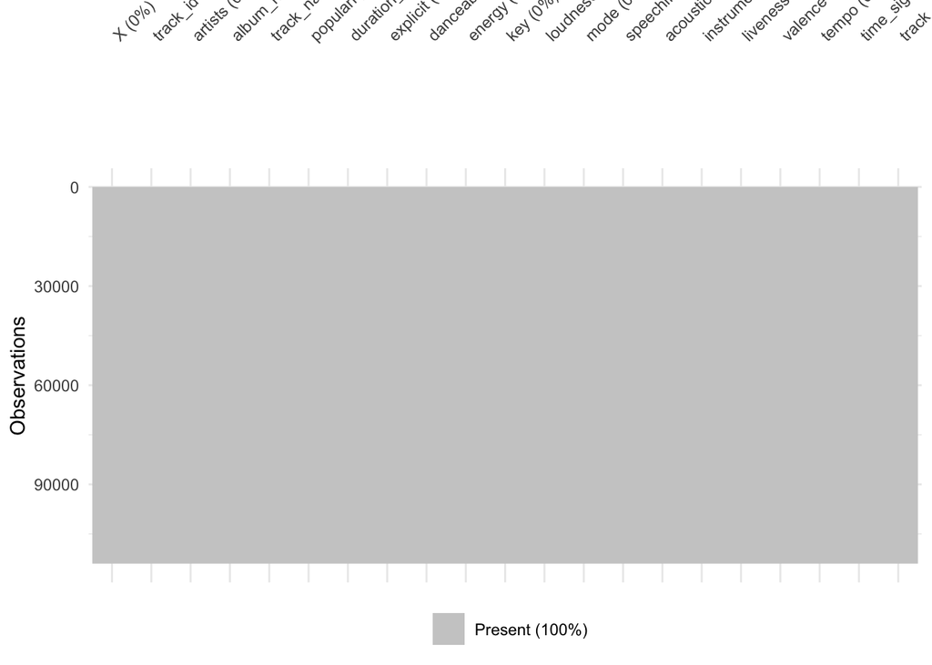

```r
vis_miss(spotify_df, warn_large_data = FALSE)
```

#### Target Imbalance

An analysis of the target variable, `track_genre`, reveals 114 distinct categories containing exactly 1,000 instances each, resulting in a perfectly balanced class distribution.

```r
genre_counts <- spotify_df |> count(track_genre, sort = TRUE)

head(genre_counts)
```

```
  track_genre    n
1    acoustic 1000
2    afrobeat 1000
3    alt-rock 1000
4 alternative 1000
5     ambient 1000
6       anime 1000
```

```r
tail(genre_counts)
```

```
    track_genre    n
109       tango 1000
110      techno 1000
111      trance 1000
112    trip-hop 1000
113     turkish 1000
114 world-music 1000
```

#### Feature Distributions

While `danceability` exhibits an approximately normal distribution and can be utilized directly, `speechiness` demonstrates severe right-skewness, necessitating a logarithmic transformation to normalize its distribution.

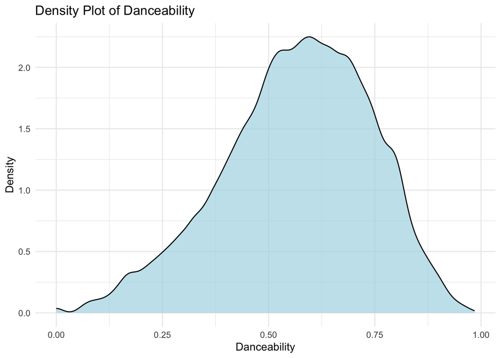

```r
dp_danceability <- ggplot(spotify_df, aes(x = danceability)) +
                   geom_density(fill = "lightblue", alpha = 0.7) +
                   theme_minimal() +
                   labs(title = "Density Plot of Danceability", x = "Danceability", y = "Density")
print(dp_danceability)
```

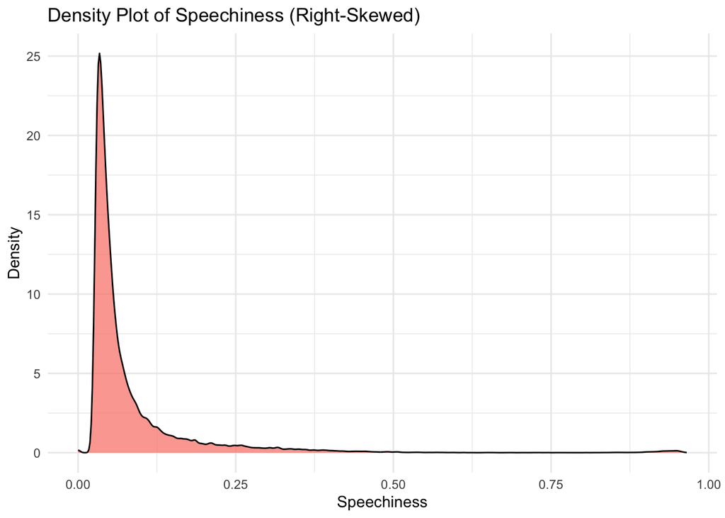

```r
dp_speechiness <- ggplot(spotify_df, aes(x = speechiness)) +
                  geom_density(fill = "salmon", alpha = 0.7) +
                  theme_minimal() +
                  labs(title = "Density Plot of Speechiness (Right-Skewed)", x = "Speechiness", y = "Density")
print(dp_speechiness)
```

#### Feature Correlation

The heatmap reveals a highly positive correlation between `energy` and `loudness`, indicating significant semantic overlap. While our tree-based ensembles (e.g., Random Forest, XGBoost) are inherently robust to such multicollinearity, identifying this relationship is crucial for accurately interpreting feature importance and streamlining future model iterations.

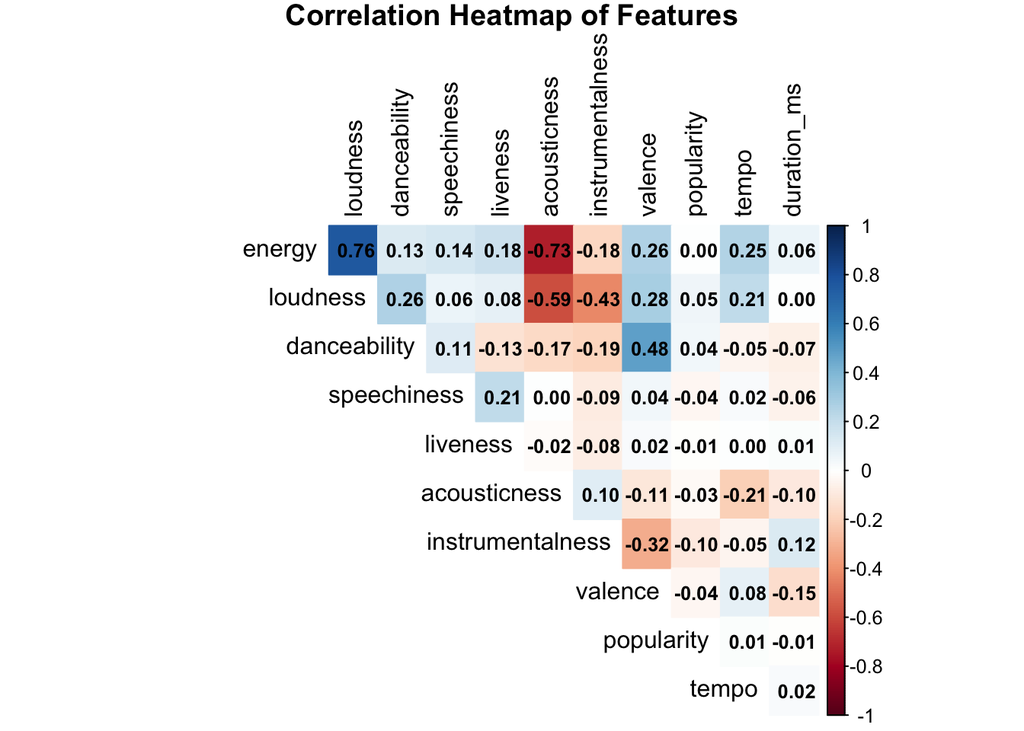

```r
numeric_features <- c("energy", "loudness", "danceability", "speechiness",
                      "liveness", "acousticness", "instrumentalness",
                      "valence", "popularity", "tempo", "duration_ms")
cor_matrix <- round(cor(spotify_df[, numeric_features], use = "complete.obs"), 2)
corrplot(cor_matrix,
         method = "color",
         type = "upper",
         addCoef.col = "black",
         diag = FALSE,
         tl.col = "black",
         number.cex = 0.8,
         title = "Correlation Heatmap of Features",
         mar = c(0,0,1,0))
```

## Feature Engineering

Feature engineering is applied to improve the representativeness of features for genre classification. This stage involves five steps:

1. Data Cleaning - remove noise and ensure correct data types
2. Distribution Stabilisation - apply simple monotonic transforms for skewed variables
3. Domain Feature Construction - add musically meaningful interaction and structure features
4. TF-IDF Encoding - derive dense artist-signal features from the `artists` field
5. Drop original text features - remove `artists`, `album_name`, and `track_name` after extracting useful metadata to prevent overfitting and reduce dimensionality

Together, these steps produce a richer tabular representation while preserving interpretability.

#### Data Cleaning

In the original dataset, the first two columns are data entrys’ sequence ID and Spotify track ID, which are not informative for genre classification. These columns are removed.

```r
spotify_df <- spotify_df[, -c(1, 2)]
```

The features with nominal data (`explicit`, `key`, `mode`, `time_signature`) and the response variable (`track_genre`) are converted to factors.

```r
spotify_df$explicit       <- as.factor(spotify_df$explicit)
spotify_df$key            <- as.factor(spotify_df$key)
spotify_df$mode           <- as.factor(spotify_df$mode)
spotify_df$time_signature <- as.factor(spotify_df$time_signature)

spotify_df$track_genre    <- as.factor(spotify_df$track_genre)
```

Duplicate entries are identified and removed to ensure data integrity.

```r
sum(duplicated(spotify_df))
```

```
[1] 577
```

```r
spotify_df <- spotify_df[!duplicated(spotify_df), ]
```

Examining the first row and structure of the cleaned dataset confirms that the data types are correct and the dataset is ready for further steps.

```r
head(spotify_df, 1)
```

```
      artists album_name track_name popularity duration_ms explicit
1 Gen Hoshino     Comedy     Comedy         73      230666    False
  danceability energy key loudness mode speechiness acousticness
1        0.676  0.461   1   -6.746    0       0.143       0.0322
  instrumentalness liveness valence  tempo time_signature track_genre
1         1.01e-06    0.358   0.715 87.917              4    acoustic
```

```r
str(spotify_df)
```

```
'data.frame':   113423 obs. of  19 variables:
 $ artists         : chr  "Gen Hoshino" "Ben Woodward" "Ingrid Michaelson;ZAYN" "Kina Grannis" ...
 $ album_name      : chr  "Comedy" "Ghost (Acoustic)" "To Begin Again" "Crazy Rich Asians (Original Motion Picture Soundtrack)" ...
 $ track_name      : chr  "Comedy" "Ghost - Acoustic" "To Begin Again" "Can't Help Falling In Love" ...
 $ popularity      : int  73 55 57 71 82 58 74 80 74 56 ...
 $ duration_ms     : int  230666 149610 210826 201933 198853 214240 229400 242946 189613 205594 ...
 $ explicit        : Factor w/ 2 levels "False","True": 1 1 1 1 1 1 1 1 1 1 ...
 $ danceability    : num  0.676 0.42 0.438 0.266 0.618 0.688 0.407 0.703 0.625 0.442 ...
 $ energy          : num  0.461 0.166 0.359 0.0596 0.443 0.481 0.147 0.444 0.414 0.632 ...
 $ key             : Factor w/ 12 levels "0","1","2","3",..: 2 2 1 1 3 7 3 12 1 2 ...
 $ loudness        : num  -6.75 -17.23 -9.73 -18.52 -9.68 ...
 $ mode            : Factor w/ 2 levels "0","1": 1 2 2 2 2 2 2 2 2 2 ...
 $ speechiness     : num  0.143 0.0763 0.0557 0.0363 0.0526 0.105 0.0355 0.0417 0.0369 0.0295 ...
 $ acousticness    : num  0.0322 0.924 0.21 0.905 0.469 0.289 0.857 0.559 0.294 0.426 ...
 $ instrumentalness: num  1.01e-06 5.56e-06 0.00 7.07e-05 0.00 0.00 2.89e-06 0.00 0.00 4.19e-03 ...
 $ liveness        : num  0.358 0.101 0.117 0.132 0.0829 0.189 0.0913 0.0973 0.151 0.0735 ...
 $ valence         : num  0.715 0.267 0.12 0.143 0.167 0.666 0.0765 0.712 0.669 0.196 ...
 $ tempo           : num  87.9 77.5 76.3 181.7 119.9 ...
 $ time_signature  : Factor w/ 5 levels "0","1","3","4",..: 4 4 4 3 4 4 3 4 4 4 ...
 $ track_genre     : Factor w/ 114 levels "acoustic","afrobeat",..: 1 1 1 1 1 1 1 1 1 1 ...
```

The features `explicit`, `key`, `mode`, and `time_signature` are now factors, while the numeric features remain as numeric types. The response variable `track_genre` is also a factor with 114 levels, corresponding to the unique genres in the dataset.

#### Distribution Stabilisation

As identified during the exploratory data analysis, the speechiness feature exhibits a severe right-skewed distribution. To stabilize the variance and mitigate the disproportionate influence of long-tail outliers, a logarithmic transformation was implemented. Specifically, the log1p function (which computes $\log(1 + x)$) was utilized. This approach safely normalizes the distribution while avoiding undefined mathematical errors ($-\infty$) for tracks that may have a speechiness value of absolute zero.

```r
spotify_df$speechiness <- log1p(spotify_df$speechiness)
```

#### Domain Feature Construction

Although the high-cardinality text features `album_name` and `track_name` are not directly suitable for model ingestion, they encapsulate valuable contextual metadata. To prevent data leakage, global text aggregation methods (such as target encoding) were bypassed in favor of deterministic, row-wise feature engineering. Through targeted regular expressions, structural metrics (e.g., character length and word count) and binary stylistic flags were extracted. Specifically, indicators for commercial formats (`album_is_single`), collaborative efforts (`has_feat`), and recording contexts (`is_remix`, `is_live`) were generated. These engineered predictors act as metadata proxies, capturing acoustic and cultural nuances—such as the inherent differences between a studio recording and a live concert—without inflating the dimensionality of the feature space.

```r
spotify_df$album_is_single <- as.integer(grepl("single|ep", spotify_df$album_name, ignore.case=TRUE))

spotify_df$name_length     <- nchar(spotify_df$track_name)
spotify_df$name_word_count <- lengths(strsplit(spotify_df$track_name, "\\s+"))
spotify_df$has_feat        <- as.integer(grepl("feat\\.|ft\\.", spotify_df$track_name, ignore.case=TRUE))
spotify_df$is_remix        <- as.integer(grepl("remix|edit|mix", spotify_df$track_name, ignore.case=TRUE))
spotify_df$is_live         <- as.integer(grepl("live|concert", spotify_df$track_name, ignore.case=TRUE))
```

To enhance the predictive power of the tree-based classifiers, a set of interaction features motivated by music theory and auditory perception was constructed. Although tree models naturally establish interaction paths, explicitly defining joint effects—such as intensity (normalized loudness coupled with `energy`) and `mood_energy` (`valence` combined with `energy`)—isolates complex acoustic signals that are weak individually but highly informative when paired. For instance, `acoustic_vocal` was derived to pinpoint unplugged, vocal-heavy genres, while a `groove_index` was engineered to quantify the relationship between danceability and BPM.

Furthermore, the mathematical limitation inherent in the key feature was addressed. Because musical pitch classes are fundamentally circular (where key 11 wraps around to key 0), treating them as simple continuous or ordinal integers imposes false distances. This was resolved by applying a cyclical sine/cosine transformation (`key_sin`, `key_cos`). This geometric projection preserves the true proximity of musical keys on a unit circle, ensuring that the algorithm accurately interprets harmonic similarities.

In detail, the following features were engineered:

```r
spotify_df <- spotify_df |>
  mutate(
    loudness_norm    = pmin(pmax((loudness + 60) / 60, 0), 1),
    intensity        = energy * loudness_norm,
    groove_index     = danceability / (tempo + 1e-6),
    acoustic_vocal   = acousticness * (1 - instrumentalness),
    mood_energy      = valence * energy,
    speech_energy    = speechiness * energy,
    energy_acoustic  = energy * (1 - acousticness),
    dance_tempo      = danceability * tempo,
    tempo_bucket     = cut(tempo,
                           breaks = c(-Inf, log1p(90), log1p(120), log1p(150), Inf),
                           labels = c("slow", "mid", "fast", "very_fast"),
                           ordered_result = TRUE),
    key_num          = suppressWarnings(as.integer(as.character(key))),
    key_unknown      = as.integer(is.na(key_num) | key_num < 0),
    key_sin          = ifelse(key_unknown == 1, 0, sin(2 * pi * key_num / 12)),
    key_cos          = ifelse(key_unknown == 1, 0, cos(2 * pi * key_num / 12))
  ) |>
  select(-key_num)
```

#### TF-IDF Encoding of Artists

```r
# Replace ";" separator with space so each artist name is a separate token
spotify_df$artists_text <- gsub(";", " ", spotify_df$artists, fixed = TRUE)

tfidf_rec <- recipe(~ artists_text, data = spotify_df) |>
step_tokenize(artists_text) |>
step_tokenfilter(artists_text, max_tokens = 50) |>
step_tfidf(artists_text)

tfidf_prep <- prep(tfidf_rec, training = spotify_df)
tfidf_cols <- bake(tfidf_prep, new_data = spotify_df)

names(tfidf_cols) <- sub("^tfidf_artists_text_", "tfidf_artist_", names(tfidf_cols))

spotify_df <- bind_cols(spotify_df, tfidf_cols)
cat("Artist TF-IDF features added:", ncol(tfidf_cols), "\n")
```

```
Artist TF-IDF features added: 50
```

```r
cat("Total features now:          ", ncol(spotify_df) - 1L, "\n")
```

```
Total features now:           87
```

```r
# Drop the temporary helper column
spotify_df$artists_text <- NULL
```

Original text features `artists`, `album_name`, `track_name` are removed as they are not suitable for direct model input.

```r
spotify_df <- spotify_df[,
!(names(spotify_df) %in% c("artists", "album_name", "track_name"))]
spotify_df$tempo_bucket <- as.factor(spotify_df$tempo_bucket)
```

Examining the first row and structure of the transformed dataset confirms that the new features have been successfully created and the original text columns have been removed.

```r
head(spotify_df, 1)
```

```
  popularity duration_ms explicit danceability energy key loudness mode
1         73      230666    False        0.676  0.461   1   -6.746    0
  speechiness acousticness instrumentalness liveness valence  tempo
1   0.1336564       0.0322         1.01e-06    0.358   0.715 87.917
  time_signature track_genre album_is_single name_length name_word_count
1              4    acoustic               0           6               1
  has_feat is_remix is_live loudness_norm intensity groove_index acoustic_vocal
1        0        0       0     0.8875667 0.4091682   0.00768907     0.03219997
  mood_energy speech_energy energy_acoustic dance_tempo tempo_bucket
1    0.329615    0.06161559       0.4461558    59.43189    very_fast
  key_unknown key_sin   key_cos tfidf_artist_a tfidf_artist_and
1           0     0.5 0.8660254              0                0
  tfidf_artist_bad tfidf_artist_balvin tfidf_artist_band tfidf_artist_black
1                0                   0                 0                  0
  tfidf_artist_boy tfidf_artist_brothers tfidf_artist_brown tfidf_artist_bunny
1                0                     0                  0                  0
  tfidf_artist_cast tfidf_artist_chris tfidf_artist_da tfidf_artist_daddy
1                 0                  0               0                  0
  tfidf_artist_david tfidf_artist_de tfidf_artist_dj tfidf_artist_do
1                  0               0               0               0
  tfidf_artist_don tfidf_artist_e tfidf_artist_el tfidf_artist_ella
1                0              0               0                 0
  tfidf_artist_for tfidf_artist_g tfidf_artist_george tfidf_artist_in
1                0              0                   0               0
  tfidf_artist_j tfidf_artist_james tfidf_artist_john tfidf_artist_jones
1              0                  0                 0                  0
  tfidf_artist_king tfidf_artist_la tfidf_artist_little tfidf_artist_los
1                 0               0                   0                0
  tfidf_artist_martin tfidf_artist_mc tfidf_artist_michael tfidf_artist_of
1                   0               0                    0               0
  tfidf_artist_omar tfidf_artist_orchestra tfidf_artist_paul
1                 0                      0                 0
  tfidf_artist_sebastian tfidf_artist_singh tfidf_artist_sounds
1                      0                  0                   0
  tfidf_artist_the tfidf_artist_van tfidf_artist_white tfidf_artist_williams
1                0                0                  0                     0
  tfidf_artist_y tfidf_artist_yankee
1              0                   0
```

```r
str(spotify_df)
```

```
'data.frame':   113423 obs. of  84 variables:
 $ popularity            : int  73 55 57 71 82 58 74 80 74 56 ...
 $ duration_ms           : int  230666 149610 210826 201933 198853 214240 229400 242946 189613 205594 ...
 $ explicit              : Factor w/ 2 levels "False","True": 1 1 1 1 1 1 1 1 1 1 ...
 $ danceability          : num  0.676 0.42 0.438 0.266 0.618 0.688 0.407 0.703 0.625 0.442 ...
 $ energy                : num  0.461 0.166 0.359 0.0596 0.443 0.481 0.147 0.444 0.414 0.632 ...
 $ key                   : Factor w/ 12 levels "0","1","2","3",..: 2 2 1 1 3 7 3 12 1 2 ...
 $ loudness              : num  -6.75 -17.23 -9.73 -18.52 -9.68 ...
 $ mode                  : Factor w/ 2 levels "0","1": 1 2 2 2 2 2 2 2 2 2 ...
 $ speechiness           : num  0.1337 0.0735 0.0542 0.0357 0.0513 ...
 $ acousticness          : num  0.0322 0.924 0.21 0.905 0.469 0.289 0.857 0.559 0.294 0.426 ...
 $ instrumentalness      : num  1.01e-06 5.56e-06 0.00 7.07e-05 0.00 0.00 2.89e-06 0.00 0.00 4.19e-03 ...
 $ liveness              : num  0.358 0.101 0.117 0.132 0.0829 0.189 0.0913 0.0973 0.151 0.0735 ...
 $ valence               : num  0.715 0.267 0.12 0.143 0.167 0.666 0.0765 0.712 0.669 0.196 ...
 $ tempo                 : num  87.9 77.5 76.3 181.7 119.9 ...
```

[output cut: 70 more lines]

## Classification Algorithms and Model Selection

Given the heterogeneous mix of continuous, nominal, and engineered features, tree-based ensemble methods were selected as the core analytical framework. These models inherently bypass the need for feature scaling and effectively capture the non-linear interactions critical to genre differentiation. A Random Forest classifier was utilized to establish a strong predictive baseline. Subsequently, an XGBoost model was implemented to further optimize classification performance across the 114 distinct classes. Both algorithms inherently yield feature importance scores, facilitating deep post-hoc interpretation. Model configurations were strictly optimized through cross-validated grid search, with overall performance evaluated against accuracy, precision, recall, and F1-score metrics.

## Model Training and Hyperparameter Tuning

#### Dataset Splitting

The dataset was split into training and testing sets using an 80/20 ratio, ensuring that the distribution of genres is preserved in both sets.

```r
set.seed(5003)

train_idx <- createDataPartition(spotify_df$track_genre, p = 0.8, list = FALSE)
train_df  <- spotify_df[train_idx, ]
test_df   <- spotify_df[-train_idx, ]

cat("Train size:", nrow(train_df), "\n")
```

```
Train size: 90793
```

```r
cat("Test size: ", nrow(test_df),  "\n")
```

```
Test size:  22630
```

```r
ctrl <- trainControl(
  method    = "cv",
  number    = 5,
  verboseIter = TRUE,
  classProbs  = TRUE,
  savePredictions = "final"
)
```

#### Random Forest Model

A computationally efficient, two-phase tuning pipeline was developed to optimize the Random Forest model. First, a 5-fold cross-validated grid search was conducted to evaluate structural parameters, specifically mtry (3 values) and max.depth (4 values). The number of trees was temporarily fixed at 100 to reduce computational overhead. Cross-validation was specifically chosen for this step to ensure an unbiased evaluation of the tree structures.

Following the identification of the optimal mtry and max.depth, the second phase focused on scaling the ensemble size. The model was trained across a sequence of num.trees ranging from 100 to 500. For this parameter, Out-Of-Bag (OOB) accuracy was leveraged as the evaluation metric, as it provides a highly efficient and sufficiently accurate estimate for the inherently monotonic relationship between tree count and model performance. The final model was compiled using the combination of parameters that yielded the highest overall accuracy.

```r
p <- ncol(train_df) - 1L

# ── Phase 1: 5-fold CV grid search over mtry × max.depth (100 trees) ──────────
k      <- 5L
folds  <- createFolds(train_df$track_genre, k = k, list = TRUE, returnTrain = TRUE)

rf_grid <- expand.grid(
  mtry      = c(floor(sqrt(p)), floor(p / 4), floor(p / 3)),
  max.depth = c(10L, 20L, 30L, 0L),
  stringsAsFactors = FALSE
)
rf_grid$cv_accuracy <- NA_real_

for (i in seq_len(nrow(rf_grid))) {
  fold_acc <- numeric(k)
  for (f in seq_len(k)) {
    cv_train <- train_df[ folds[[f]], ]
    cv_val   <- train_df[-folds[[f]], ]
    m <- ranger(
      formula        = track_genre ~ .,
      data           = cv_train,
      num.trees      = 100L,
      mtry           = rf_grid$mtry[i],
      max.depth      = rf_grid$max.depth[i],
      min.node.size  = 5L,
      classification = TRUE,
      num.threads    = parallel::detectCores()
    )
    fold_acc[f] <- mean(predict(m, data = cv_val)$predictions == cv_val$track_genre)
  }
  rf_grid$cv_accuracy[i] <- mean(fold_acc)
}
best_rf <- rf_grid[which.max(rf_grid$cv_accuracy), ]
cat("Phase 1 CV results:\n"); print(rf_grid[order(-rf_grid$cv_accuracy), ])
```

```
Phase 1 CV results:
```

```
   mtry max.depth cv_accuracy
8    20        30   0.3456657
12   27         0   0.3455333
9    27        30   0.3454564
11   20         0   0.3449827
10    9         0   0.3377026
7     9        30   0.3358744
6    27        20   0.3354446
5    20        20   0.3343763
4     9        20   0.3237918
3    27        10   0.2540726
2    20        10   0.2517156
1     9        10   0.2337414
```

```r
cat("\nBest mtry:", best_rf$mtry, "| Best max.depth:", best_rf$max.depth,
    "| CV Accuracy:", round(best_rf$cv_accuracy, 4), "\n")
```

```
Best mtry: 20 | Best max.depth: 30 | CV Accuracy: 0.3457
```

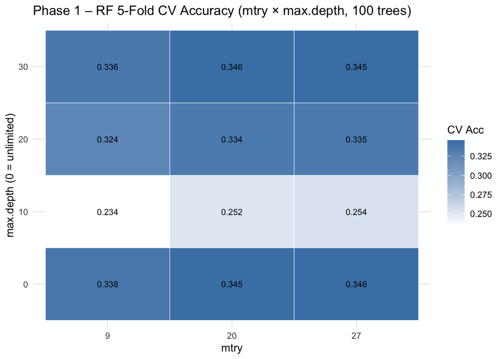

```r
# Heatmap of Phase 1 CV results
ggplot(rf_grid,
       aes(x = factor(mtry), y = factor(max.depth), fill = cv_accuracy)) +
  geom_tile(colour = "white") +
  geom_text(aes(label = round(cv_accuracy, 3)), size = 3) +
  scale_fill_gradient(low = "white", high = "steelblue") +
  labs(title = paste0("Phase 1 – RF ", k, "-Fold CV Accuracy (mtry × max.depth, 100 trees)"),
       x = "mtry", y = "max.depth (0 = unlimited)", fill = "CV Acc") +
  theme_minimal()
```

```r
# ── Phase 2: tune num.trees with best mtry & max.depth (OOB, fast) ────────────
tree_grid    <- c(100L, 200L, 300L, 400L, 500L)
tree_results <- data.frame(num.trees = tree_grid, oob_accuracy = NA_real_)
rf_model     <- NULL

for (i in seq_along(tree_grid)) {
  m <- ranger(
    formula        = track_genre ~ .,
    data           = train_df,
    num.trees      = tree_grid[i],
    mtry           = best_rf$mtry,
    max.depth      = best_rf$max.depth,
    min.node.size  = 5L,
    classification = TRUE,
    num.threads    = parallel::detectCores()
  )
  tree_results$oob_accuracy[i] <- 1 - m$prediction.error
  if (is.null(rf_model) ||
      (1 - m$prediction.error) > max(tree_results$oob_accuracy[-i], na.rm = TRUE)) {
    rf_model <- m
  }
}
print(tree_results)
```

```
  num.trees oob_accuracy
1       100    0.3266111
2       200    0.3384182
3       300    0.3429119
4       400    0.3448283
5       500    0.3463593
```

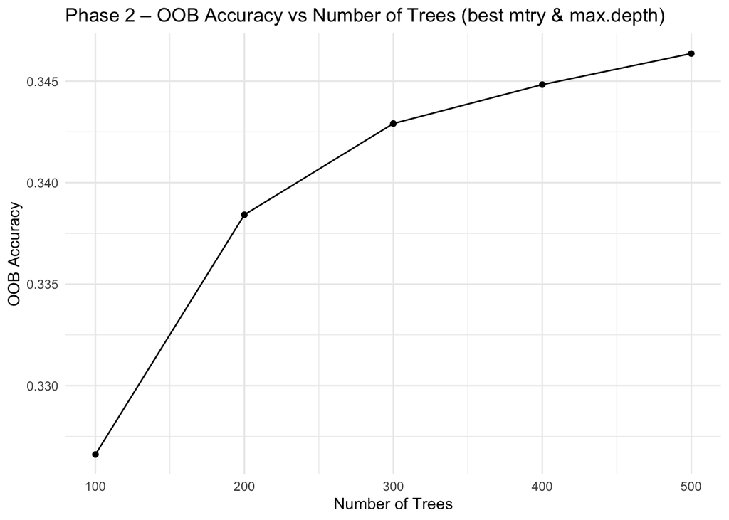

```r
ggplot(tree_results, aes(x = num.trees, y = oob_accuracy)) +
  geom_line() +
  geom_point() +
  labs(title = "Phase 2 – OOB Accuracy vs Number of Trees (best mtry & max.depth)",
       x = "Number of Trees", y = "OOB Accuracy") +
  theme_minimal()
```

```r
best_trees <- tree_results$num.trees[which.max(tree_results$oob_accuracy)]
cat("Best num.trees:", best_trees, "\n")
```

```
Best num.trees: 500
```

The Random Forest hyperparameter tuning identified mtry = 20 and max.depth = 30 as the optimal structural configuration via 5-fold cross-validation (CV accuracy = 0.346). Phase 1 results confirm that shallow trees (max.depth = 10) substantially underfit the 114-class problem, while deeper and unlimited-depth trees converge to similar performance, indicating that the decision boundaries require at least moderate depth to capture genre-discriminative interactions. The Phase 2 OOB sweep reveals a monotonically increasing accuracy curve that plateaus around 400–500 trees, with the final model at 500 trees achieving an OOB accuracy of approximately 0.347.

#### XGBoost Model

```r
# ── Build model matrices ───────────────────────────────────────────────────────
train_matrix <- model.matrix(track_genre ~ . - 1, data = train_df)
test_matrix  <- model.matrix(track_genre ~ . - 1, data = test_df)

genre_levels <- levels(train_df$track_genre)
train_labels <- as.integer(train_df$track_genre) - 1
test_labels  <- as.integer(test_df$track_genre)  - 1

dtrain <- xgb.DMatrix(data = train_matrix, label = train_labels)
dtest  <- xgb.DMatrix(data = test_matrix,  label = test_labels)

# ── Phase 1: 5-fold CV grid search over max_depth × eta ───────────────────────
xgb_grid <- expand.grid(
  max_depth = c(4L, 6L, 8L),
  eta       = c(0.05, 0.1, 0.2),
  stringsAsFactors = FALSE
)
xgb_grid$best_nrounds <- NA_integer_
xgb_grid$cv_merror    <- NA_real_

for (i in seq_len(nrow(xgb_grid))) {
  cv_res <- xgb.cv(
    params = list(
      objective        = "multi:softmax",
      num_class        = length(genre_levels),
      max_depth        = xgb_grid$max_depth[i],
      eta              = xgb_grid$eta[i],
      subsample        = 0.8,
      colsample_bytree = 0.8,
      eval_metric      = "merror",
      nthread          = parallel::detectCores(),
      tree_method      = "hist"
    ),
    data                  = dtrain,
    nrounds               = 20,
    nfold                 = 5,
    early_stopping_rounds = 5,
    verbose               = 0
  )
  best_iter <- if (!is.null(cv_res$best_iteration) && length(cv_res$best_iteration) > 0)
                 cv_res$best_iteration
               else
                 nrow(cv_res$evaluation_log)
  xgb_grid$best_nrounds[i] <- best_iter
  xgb_grid$cv_merror[i]    <- cv_res$evaluation_log$test_merror_mean[best_iter]
}

xgb_grid$cv_accuracy <- 1 - xgb_grid$cv_merror
best_xgb <- xgb_grid[which.min(xgb_grid$cv_merror), ]

cat("Phase 1 CV results:\n"); print(xgb_grid[order(xgb_grid$cv_merror), ])
```

```
Phase 1 CV results:
```

```
  max_depth  eta best_nrounds cv_merror cv_accuracy
3         8 0.05           20 0.6471973   0.3528027
6         8 0.10           20 0.6494993   0.3505007
5         6 0.10           20 0.6534977   0.3465023
8         6 0.20           20 0.6573963   0.3426037
2         6 0.05           20 0.6585857   0.3414143
9         8 0.20           20 0.6603705   0.3396295
7         4 0.20           20 0.6674965   0.3325035
4         4 0.10           20 0.6753167   0.3246833
1         4 0.05           20 0.6856587   0.3143413
```

```r
cat("\nBest max_depth:", best_xgb$max_depth,
    "| Best eta:",      best_xgb$eta,
    "| Best nrounds:",  best_xgb$best_nrounds,
    "| CV Accuracy:",   round(best_xgb$cv_accuracy, 4), "\n")
```

```
Best max_depth: 8 | Best eta: 0.05 | Best nrounds: 20 | CV Accuracy: 0.3528
```

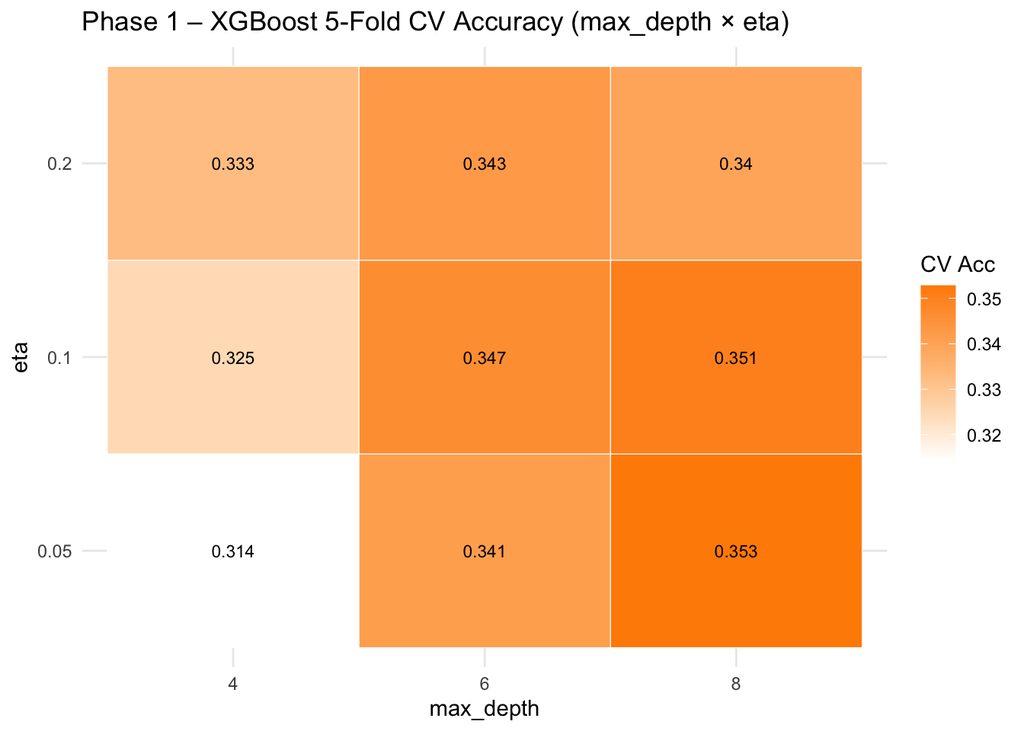

```r
# Heatmap of Phase 1 CV results
ggplot(xgb_grid,
       aes(x = factor(max_depth), y = factor(eta), fill = cv_accuracy)) +
  geom_tile(colour = "white") +
  geom_text(aes(label = round(cv_accuracy, 3)), size = 3) +
  scale_fill_gradient(low = "white", high = "darkorange") +
  labs(title = "Phase 1 – XGBoost 5-Fold CV Accuracy (max_depth \u00d7 eta)",
       x = "max_depth", y = "eta", fill = "CV Acc") +
  theme_minimal()
```

```r
# ── Phase 2: train final model with best hyperparameters ──────────────────────
xgb_model <- xgb.train(
  params = list(
    objective        = "multi:softmax",
    num_class        = length(genre_levels),
    max_depth        = best_xgb$max_depth,
    eta              = best_xgb$eta,
    subsample        = 0.8,
    colsample_bytree = 0.8,
    eval_metric      = "merror",
    nthread          = parallel::detectCores(),
    tree_method      = "hist"
  ),
  data          = dtrain,
  nrounds       = best_xgb$best_nrounds,
  watchlist     = list(train = dtrain, test = dtest),
  verbose       = 1,
  print_every_n = 20
)
# Predict
xgb_pred_int <- predict(xgb_model, dtest)
xgb_pred     <- factor(genre_levels[xgb_pred_int + 1], levels = genre_levels)
```

## Classification Performance Evaluation

To rigorously assess predictive efficacy, the finalized Random Forest and XGBoost models were evaluated against the independent hold-out test set. Performance was quantified using a standard suite of classification metrics: Accuracy, Precision, Recall, and the F1-score. Given the high-cardinality nature of the 114-class dataset, performance metrics (Precision, Recall, and F1) were aggregated using a macro-averaging approach. This ensures that every genre is weighted equally in the final summary, preventing statistically dominant or easier-to-predict classes from artificially inflating the overall scores.

A comprehensive summary table was constructed to contrast the macro-averaged performance of both tree-based ensembles. To facilitate visual interpretation, these metrics were further mapped onto a grouped bar chart, allowing for a direct, side-by-side comparative analysis of the two models. Finally, granular per-class metrics were extracted to pinpoint specific genres where the models exhibit high predictive confidence versus areas highly susceptible to inter-class confusion.

```r
# Random Forest predictions & confusion matrix
rf_pred <- predict(rf_model, data = test_df)$predictions
rf_cm   <- confusionMatrix(rf_pred, test_df$track_genre)

# XGBoost confusion matrix (xgb_pred already computed above)
xgb_cm  <- confusionMatrix(xgb_pred, test_df$track_genre)

# ── Summary table ─────────────────────────────────────────────────────────────
perf_summary <- data.frame(
  Model     = c("Random Forest", "XGBoost"),
  Accuracy  = c(rf_cm$overall["Accuracy"],  xgb_cm$overall["Accuracy"]),
  Precision = c(mean(rf_cm$byClass[, "Precision"], na.rm = TRUE),
                mean(xgb_cm$byClass[, "Precision"], na.rm = TRUE)),
  Recall    = c(mean(rf_cm$byClass[, "Recall"], na.rm = TRUE),
                mean(xgb_cm$byClass[, "Recall"], na.rm = TRUE)),
  F1        = c(mean(rf_cm$byClass[, "F1"], na.rm = TRUE),
                mean(xgb_cm$byClass[, "F1"], na.rm = TRUE))
)
perf_summary[, -1] <- round(perf_summary[, -1], 4)
print(perf_summary)
```

```
          Model Accuracy Precision Recall     F1
1 Random Forest   0.3514    0.3464 0.3519 0.3445
2       XGBoost   0.3557    0.3490 0.3561 0.3453
```

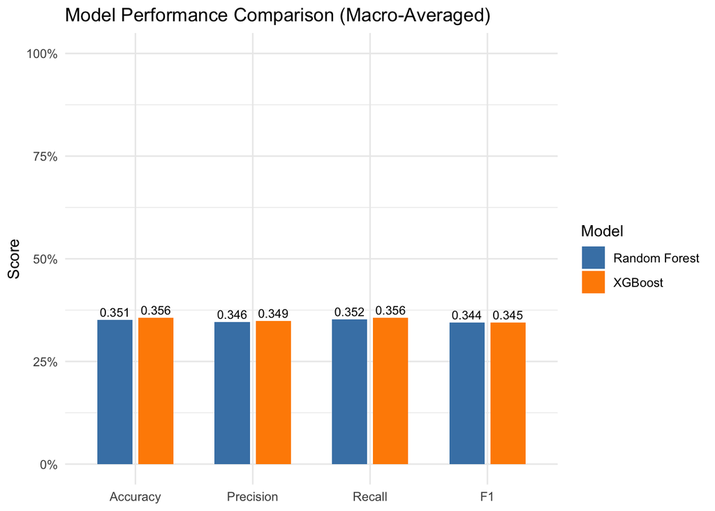

```r
# ── Bar chart comparison ───────────────────────────────────────────────────────
perf_long <- tidyr::pivot_longer(perf_summary, -Model,
                                 names_to = "Metric", values_to = "Value")
perf_long$Metric <- factor(perf_long$Metric,
                           levels = c("Accuracy", "Precision", "Recall", "F1"))

ggplot(perf_long, aes(x = Metric, y = Value, fill = Model)) +
  geom_col(position = position_dodge(0.7), width = 0.6) +
  geom_text(aes(label = sprintf("%.3f", Value)),
            position = position_dodge(0.7), vjust = -0.4, size = 3) +
  scale_y_continuous(limits = c(0, 1), labels = scales::percent_format(accuracy = 1)) +
  scale_fill_manual(values = c("Random Forest" = "steelblue",
                                "XGBoost"       = "darkorange")) +
  labs(title = "Model Performance Comparison (Macro-Averaged)",
       x = NULL, y = "Score", fill = "Model") +
  theme_minimal()
```

```r
# ── Per-class metrics ─────────────────────────────────────────────────────────
cat("\n--- Random Forest: Per-Class Metrics ---\n")
```

```
--- Random Forest: Per-Class Metrics ---
```

```r
print(rf_cm$byClass[, c("Precision", "Recall", "F1")])
```

```
                          Precision     Recall         F1
Class: acoustic          0.23404255 0.27500000 0.25287356
Class: afrobeat          0.47647059 0.40703518 0.43902439
Class: alt-rock          0.04938272 0.04040404 0.04444444
Class: alternative       0.11855670 0.11616162 0.11734694
Class: ambient           0.27777778 0.30150754 0.28915663
Class: anime             0.25517241 0.18592965 0.21511628
Class: black-metal       0.57826087 0.66834171 0.62004662
Class: bluegrass         0.40549828 0.59296482 0.48163265
Class: blues             0.15126050 0.09045226 0.11320755
Class: brazil            0.14666667 0.16582915 0.15566038
Class: breakbeat         0.57803468 0.50251256 0.53763441
Class: british           0.18478261 0.08542714 0.11683849
Class: cantopop          0.47465438 0.51758794 0.49519231
Class: chicago-house     0.63402062 0.61809045 0.62595420
Class: children          0.58895706 0.48241206 0.53038674
Class: chill             0.16956522 0.19597990 0.18181818
Class: classical         0.56284153 0.55376344 0.55826558
Class: club              0.59200000 0.37185930 0.45679012
Class: comedy            0.96531792 0.83919598 0.89784946
Class: country           0.50892857 0.57286432 0.53900709
Class: dance             0.30113636 0.27604167 0.28804348
Class: dancehall         0.35242291 0.40201005 0.37558685
Class: death-metal       0.32075472 0.42713568 0.36637931
Class: deep-house        0.17973856 0.27638191 0.21782178
Class: detroit-techno    0.61290323 0.57286432 0.59220779
Class: disco             0.30344828 0.22110553 0.25581395
Class: disney            0.54421769 0.40201005 0.46242775
Class: drum-and-bass     0.68156425 0.61306533 0.64550265
Class: dub               0.10191083 0.08040201 0.08988764
Class: dubstep           0.11743772 0.16582915 0.13750000
Class: edm               0.06632653 0.06565657 0.06598985
Class: electro           0.20606061 0.17171717 0.18732782
Class: electronic        0.11594203 0.04000000 0.05947955
Class: emo               0.17985612 0.12562814 0.14792899
Class: folk              0.10294118 0.07070707 0.08383234
Class: forro             0.46785714 0.65829146 0.54697286
Class: french            0.35031847 0.27638191 0.30898876
Class: funk              0.50359712 0.35175879 0.41420118
Class: garage            0.23076923 0.18090452 0.20281690
```

[output cut: 60 more lines]

```
Class: singer-songwriter 0.04504505 0.05025126 0.04750594
Class: ska               0.32083333 0.38500000 0.35000000
Class: sleep             0.90306122 0.88500000 0.89393939
Class: songwriter        0.03141361 0.03015075 0.03076923
Class: soul              0.23577236 0.29145729 0.26067416
Class: spanish           0.30508475 0.18000000 0.22641509
Class: study             0.65454545 0.90452261 0.75949367
Class: swedish           0.32031250 0.20500000 0.25000000
Class: synth-pop         0.26315789 0.15075377 0.19169329
Class: tango             0.68240343 0.79500000 0.73441109
Class: techno            0.11904762 0.10000000 0.10869565
Class: trance            0.37959184 0.46733668 0.41891892
Class: trip-hop          0.32544379 0.27638191 0.29891304
Class: turkish           0.27687296 0.42713568 0.33596838
Class: world-music       0.55851064 0.52763819 0.54263566
```

```r
cat("\n--- XGBoost: Per-Class Metrics ---\n")
```

```
--- XGBoost: Per-Class Metrics ---
```

```r
print(xgb_cm$byClass[, c("Precision", "Recall", "F1")])
```

```
                          Precision     Recall         F1
Class: acoustic          0.20105820 0.19000000 0.19537275
Class: afrobeat          0.38834951 0.40201005 0.39506173
Class: alt-rock          0.08771930 0.05050505 0.06410256
Class: alternative       0.16568047 0.14141414 0.15258856
Class: ambient           0.23981900 0.26633166 0.25238095
Class: anime             0.28318584 0.16080402 0.20512821
Class: black-metal       0.59615385 0.62311558 0.60933661
Class: bluegrass         0.36054422 0.53266332 0.43002028
Class: blues             0.25806452 0.12060302 0.16438356
Class: brazil            0.18705036 0.26130653 0.21802935
Class: breakbeat         0.51578947 0.49246231 0.50385604
Class: british           0.10144928 0.03517588 0.05223881
Class: cantopop          0.46859903 0.48743719 0.47783251
Class: chicago-house     0.58469945 0.53768844 0.56020942
Class: children          0.52631579 0.45226131 0.48648649
Class: chill             0.16603774 0.22110553 0.18965517
Class: classical         0.62068966 0.58064516 0.60000000
Class: club              0.48344371 0.36683417 0.41714286
Class: comedy            0.93296089 0.83919598 0.88359788
Class: country           0.39525692 0.50251256 0.44247788
Class: dance             0.26794258 0.29166667 0.27930175
Class: dancehall         0.35353535 0.35175879 0.35264484
Class: death-metal       0.34586466 0.46231156 0.39569892
Class: deep-house        0.21904762 0.34673367 0.26848249
Class: detroit-techno    0.59895833 0.57788945 0.58823529
Class: disco             0.29220779 0.22613065 0.25495751
Class: disney            0.43859649 0.37688442 0.40540541
Class: drum-and-bass     0.63902439 0.65829146 0.64851485
Class: dub               0.11538462 0.04522613 0.06498195
Class: dubstep           0.20125786 0.32160804 0.24758221
Class: edm               0.11956522 0.11111111 0.11518325
Class: electro           0.20740741 0.14141414 0.16816817
Class: electronic        0.14102564 0.05500000 0.07913669
Class: emo               0.19760479 0.16582915 0.18032787
Class: folk              0.15294118 0.06565657 0.09187279
Class: forro             0.42105263 0.64321608 0.50894632
Class: french            0.28289474 0.21608040 0.24501425
Class: funk              0.62698413 0.39698492 0.48615385
Class: garage            0.27027027 0.25125628 0.26041667
```

[output cut: 60 more lines]

```
Class: singer-songwriter 0.05511811 0.03517588 0.04294479
Class: ska               0.30357143 0.34000000 0.32075472
Class: sleep             0.87000000 0.87000000 0.87000000
Class: songwriter        0.10000000 0.05527638 0.07119741
Class: soul              0.26486486 0.24623116 0.25520833
Class: spanish           0.22754491 0.19000000 0.20708447
Class: study             0.58362989 0.82412060 0.68333333
Class: swedish           0.25000000 0.16500000 0.19879518
Class: synth-pop         0.23770492 0.14572864 0.18068536
Class: tango             0.70531401 0.73000000 0.71744472
Class: techno            0.21985816 0.15500000 0.18181818
Class: trance            0.39090909 0.43216080 0.41050119
Class: trip-hop          0.32038835 0.33165829 0.32592593
Class: turkish           0.25212465 0.44723618 0.32246377
Class: world-music       0.55056180 0.49246231 0.51989390
```

A baseline was established using the Random Forest model, which achieved an overall test accuracy of 35.1% (Macro F1 = 0.344). XGBoost demonstrated a marginal but consistent improvement across all metrics, attaining an accuracy of 35.6% (Macro F1 = 0.345). Both results represent approximately 40 times the performance of a naive random baseline (0.88% for 114 equally likely classes), confirming that both models successfully learned meaningful acoustic and metadata patterns.

Due to the extreme high-cardinality of the target variable, rendering a complete 114x114 confusion matrix would result in severe visual overplotting and reduced interpretability. To effectively diagnose the classification behavior, a subsetted confusion matrix heatmap was constructed, isolating the top 20 most frequently occurring genres within the independent test set.

Crucially, the raw prediction frequencies were row-normalized relative to the true class (Reference). By converting absolute counts into proportional values, the color gradient intensity directly reflects the class-specific Recall (Sensitivity) along the main diagonal. Conversely, the off-diagonal elements explicitly expose the exact distribution of misclassifications. This targeted visualization strategy enables a granular inspection of semantic overlap, clearly highlighting which specific genres the Random Forest model seamlessly identifies and which clusters of genres share indistinguishable acoustic boundaries.

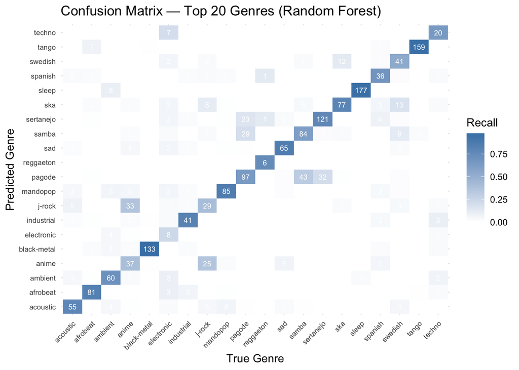

```r
# Confusion matrix heatmap for top 20 genres
top_n <- 20

# Pick top N genres by number of test samples
top_genres <- names(sort(table(test_df$track_genre), decreasing = TRUE))[1:top_n]

# Subset the confusion matrix table
cm_table <- as.data.frame(rf_cm$table)
cm_sub   <- cm_table[cm_table$Reference %in% top_genres &
                     cm_table$Prediction %in% top_genres, ]

# Normalise by true class (row) so colour = recall per cell
cm_sub <- cm_sub |>
  group_by(Reference) |>
  mutate(Proportion = Freq / sum(Freq)) |>
  ungroup()

ggplot(cm_sub, aes(x = Reference, y = Prediction, fill = Proportion)) +
  geom_tile() +
  geom_text(aes(label = Freq), size = 2.5, colour = "white") +
  scale_fill_gradient(low = "white", high = "steelblue") +
  labs(title = paste("Confusion Matrix — Top", top_n, "Genres (Random Forest)"),
       x = "True Genre", y = "Predicted Genre", fill = "Recall") +
  theme_minimal() +
  theme(axis.text.x = element_text(angle = 45, hjust = 1, size = 7),
        axis.text.y = element_text(size = 7))
```

## Conclusion

This project investigated the feasibility of high-cardinality music genre classification utilizing the Spotify Tracks Dataset (114,000 tracks across 114 genres). The analytical pipeline encompassed rigorous exploratory data analysis, domain-driven feature engineering — incorporating log transformations, music-theory-motivated interaction features, cyclical key encoding, and TF-IDF artist embeddings — and the cross-validated training and evaluation of two tree-based ensembles: Random Forest and XGBoost.

A baseline was established using the Random Forest model, which achieved an overall test accuracy of 35.1% (Macro Precision: 0.346, Recall: 0.352, F1: 0.344), optimised via a two-phase tuning pipeline that identified mtry = 20, max.depth = 30, and num.trees = 500 as the best configuration. XGBoost demonstrated a marginal but consistent improvement across all four metrics, attaining an accuracy of 35.6% (Macro Precision: 0.349, Recall: 0.356, F1: 0.345), with max_depth = 8 and eta = 0.05 selected via 5-fold cross-validated grid search. Both results represent approximately 40 times the performance of a naive random baseline (≈0.88%), confirming that both models successfully learned meaningful discriminative patterns from the acoustic and metadata features. The narrow cross-model gap (≤ 0.005 across all metrics) indicates that the primary performance ceiling is imposed by the feature representation rather than the choice of algorithm.

Granular per-class diagnostics revealed a pronounced dichotomy in classification success. Genres occupying narrow, acoustically isolated regions of the feature space, such as sleep (recall ≈ 0.885), tango (recall ≈ 0.795), and black-metal (recall ≈ 0.665), were identified with high confidence. In contrast, culturally proximate genre clusters, most notably the Brazilian popular cluster of samba, sertanejo, and pagode, which share overlapping rhythmic and harmonic profiles, exhibited systematic cross-genre confusion that no amount of hyperparameter tuning can resolve using Spotify’s high-level acoustic descriptors alone. This disparity underscores that the primary bottleneck is the inherent semantic overlap in the 114-class label space, not algorithmic deficiency.

## Future Work

To further optimize genre classification performance, future research should transition towards multi-modal deep learning and advanced architectural frameworks:

- Deep Learning for Audio and Text: The current reliance on high-level acoustic summaries and rule-based text extraction discards granular information. Future pipelines should leverage deep learning to process raw inputs. For audio, utilizing CNNs or audio transformers on mel-spectrograms can extract deep timbral features. For metadata (track_name, album_name), deploying advanced NLP models (such as BERT embeddings) can capture complex semantic and cultural nuances that traditional Boolean flags miss.
- Taxonomy Reduction: Merging acoustically indistinguishable genre pairs (e.g., punk and punk-rock) into broader super-categories would mitigate label noise and effectively reduce the complexity of the 114-class target variable.

## Footnotes

[^1]: [Spotify Tracks Dataset](https://www.kaggle.com/datasets/maharshipandya/-spotify-tracks-dataset) from Kaggle. This dataset is licensed under [Open Data Commons Open Database License (ODbL) v1.0](https://opendatacommons.org/licenses/odbl/1-0/).